# Cluster Report v3.1: POST-COVID GoiEner

Universidad de Deusto (carlos.quesada@deusto.es)

2022-02-11 10:11:43

#### List of abbreviations

##### Sets of features

- **sAggrDRM**: seasonal aggregates v2.0 (day-referenced mean)
- **sAggrP6**: seasonal aggregates v3.0 (6-period time division)

##### Datasets

- **goi**: GoiEner (including Megara and La Corriente) [ES]

##### Clustering methods

- **som**: self-organizing maps

## sAggrP6 > goi > som

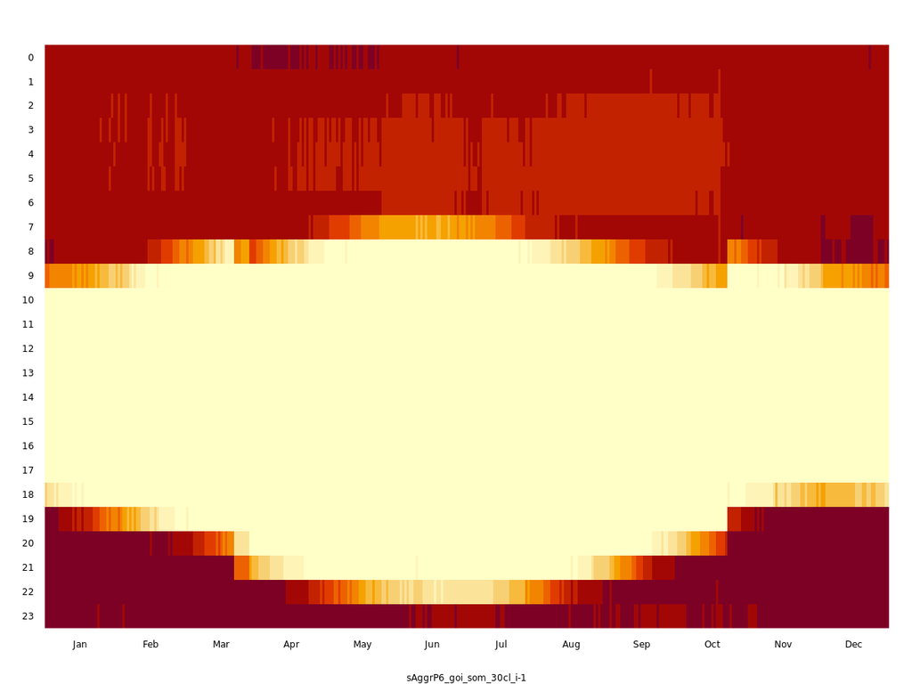

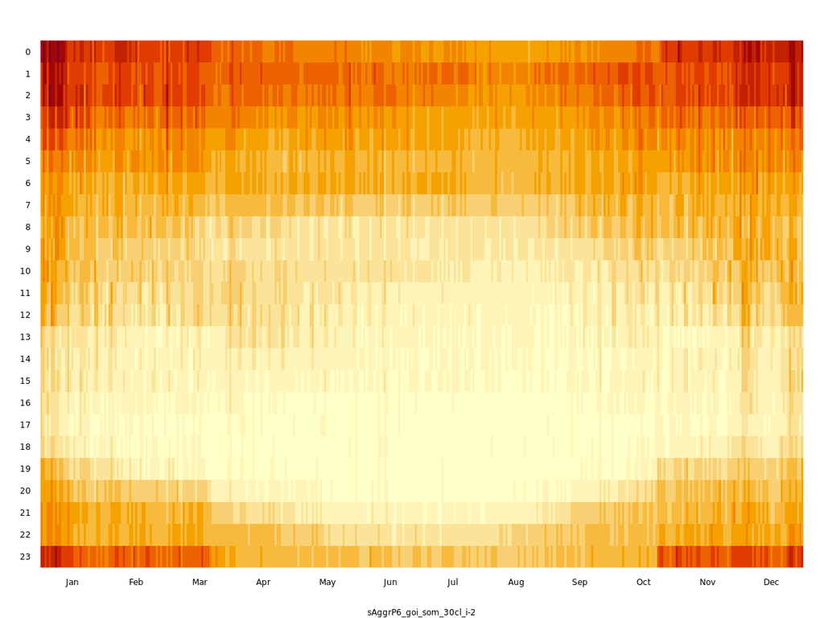

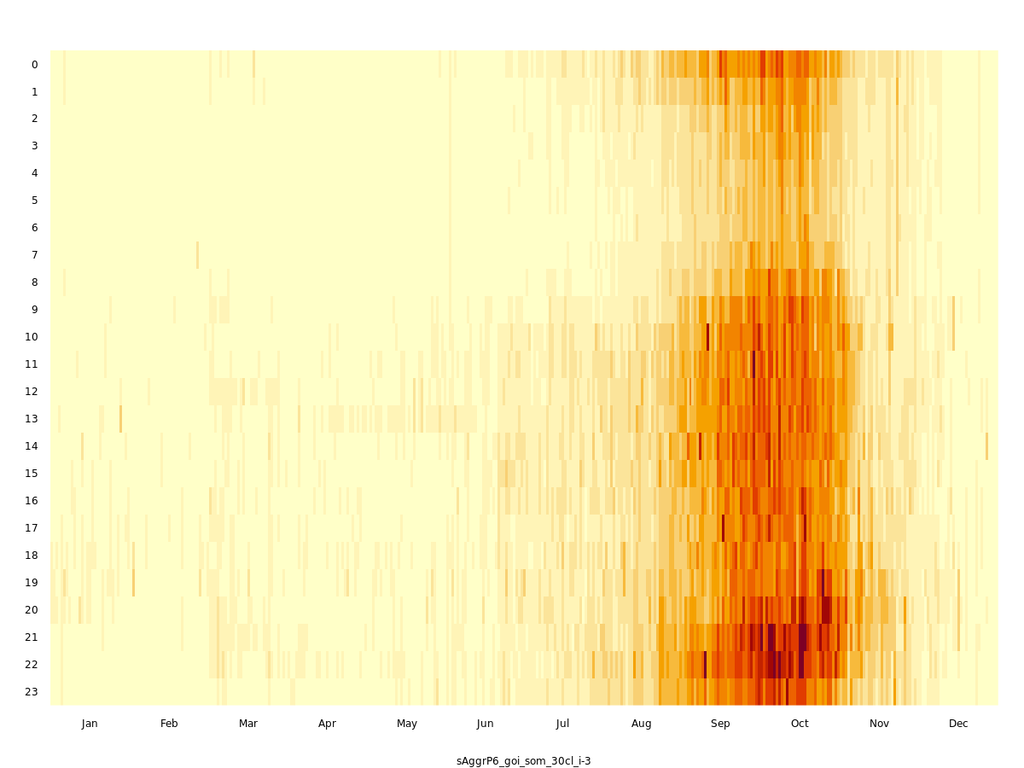

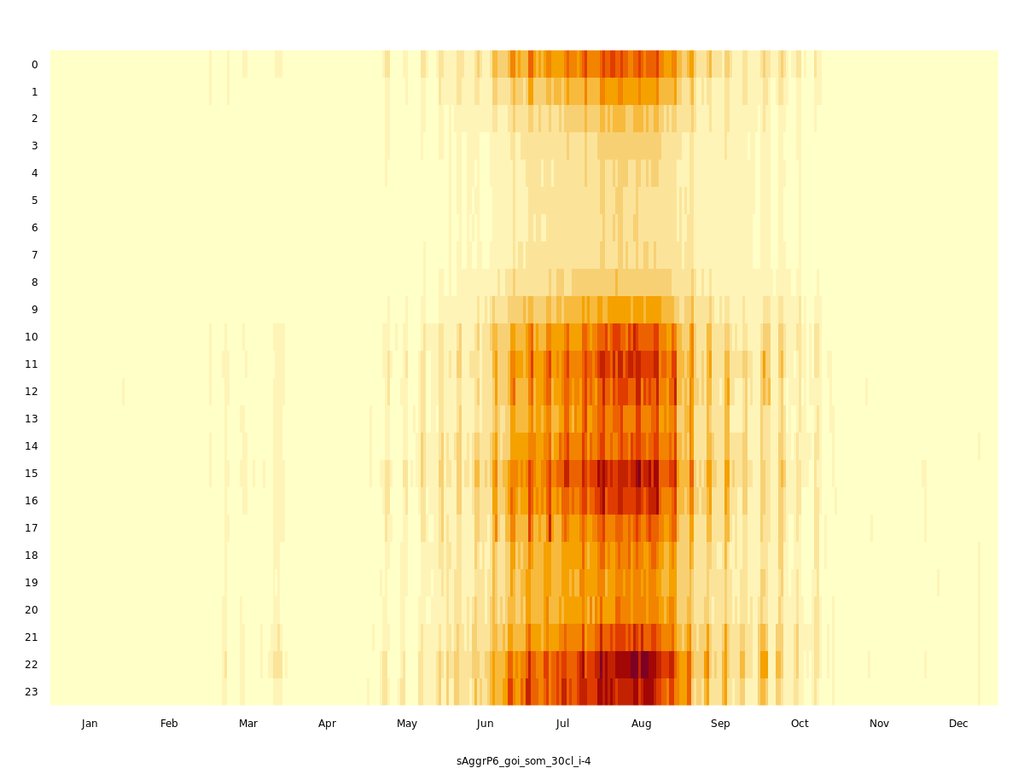

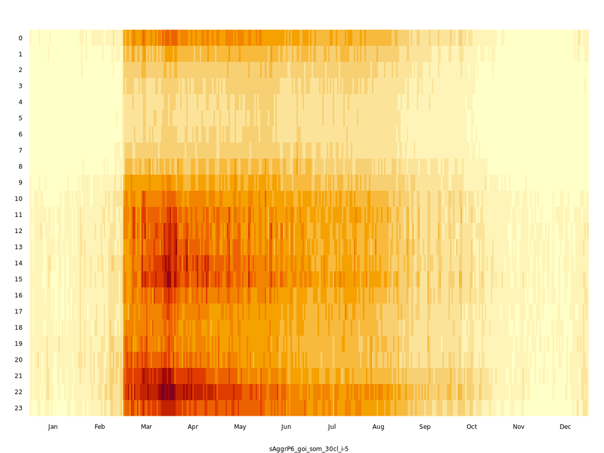

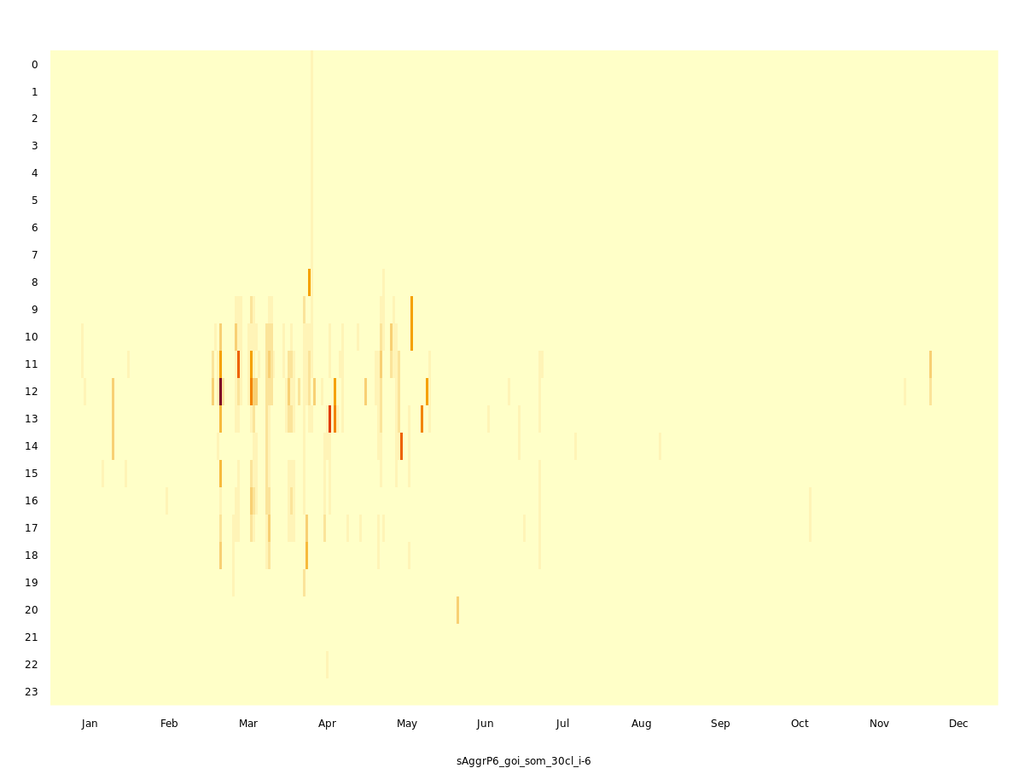

sAggrP6 > goi > som > #1

374 TS (2.3%)

sAggrP6 > goi > som > #2

166 TS (1%)

sAggrP6 > goi > som > #3

95 TS (0.6%)

sAggrP6 > goi > som > #4

200 TS (1.2%)

sAggrP6 > goi > som > #5

213 TS (1.3%)

sAggrP6 > goi > som > #6

19 TS (0.1%)

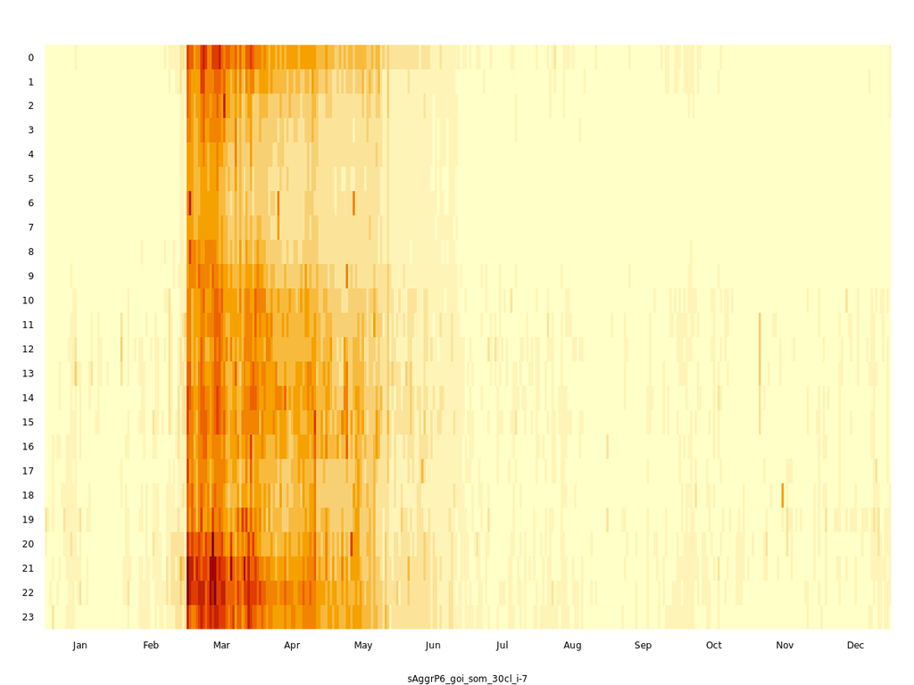

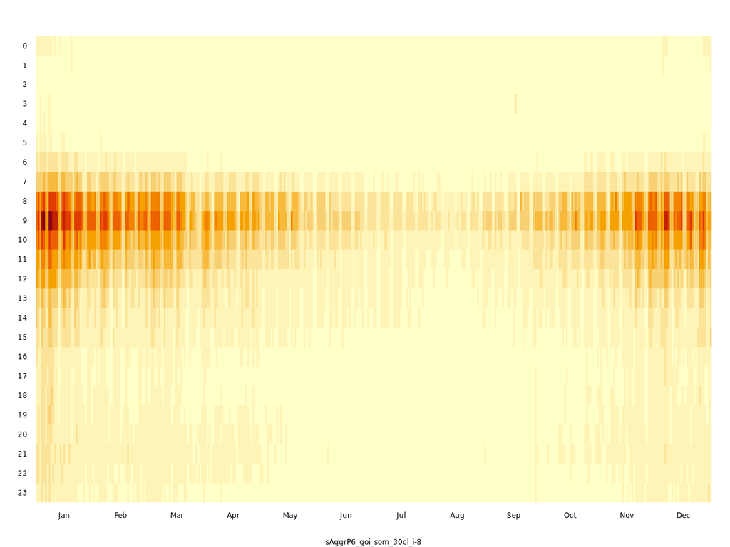

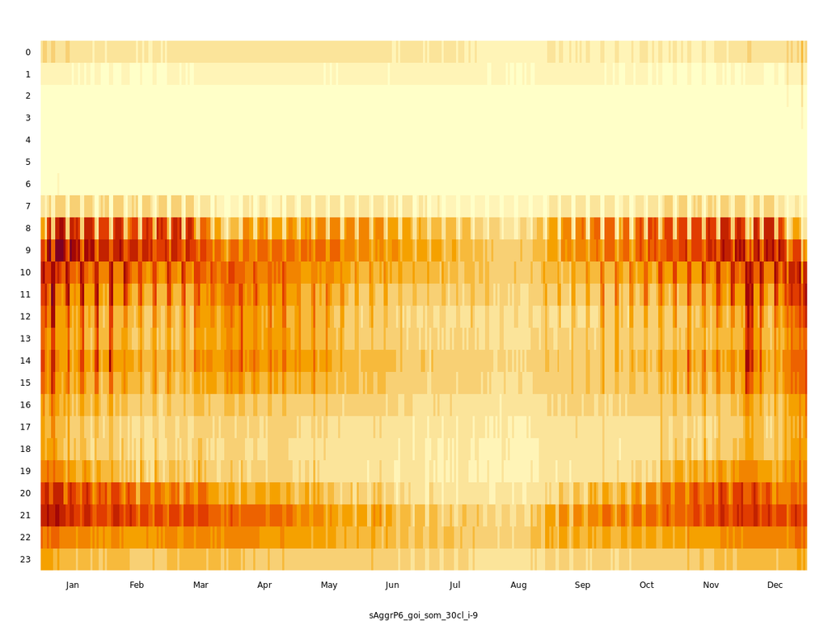

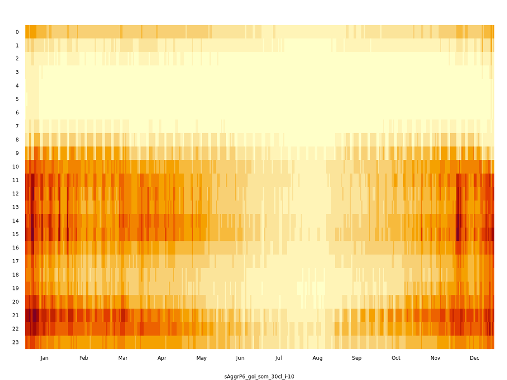

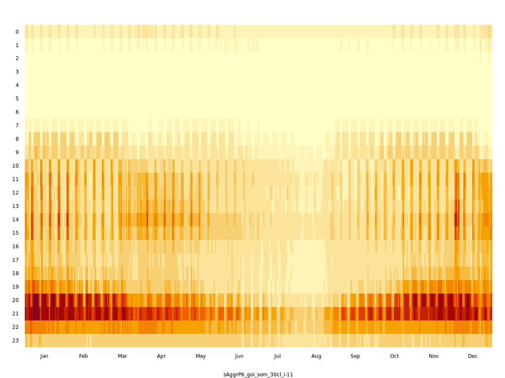

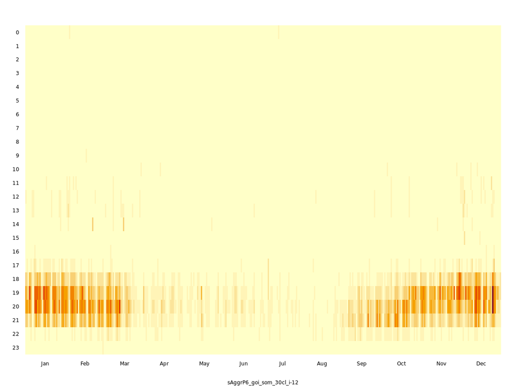

sAggrP6 > goi > som > #7

74 TS (0.5%)

sAggrP6 > goi > som > #8

103 TS (0.6%)

sAggrP6 > goi > som > #9

935 TS (5.8%)

sAggrP6 > goi > som > #10

783 TS (4.9%)

sAggrP6 > goi > som > #11

988 TS (6.1%)

sAggrP6 > goi > som > #12

75 TS (0.5%)

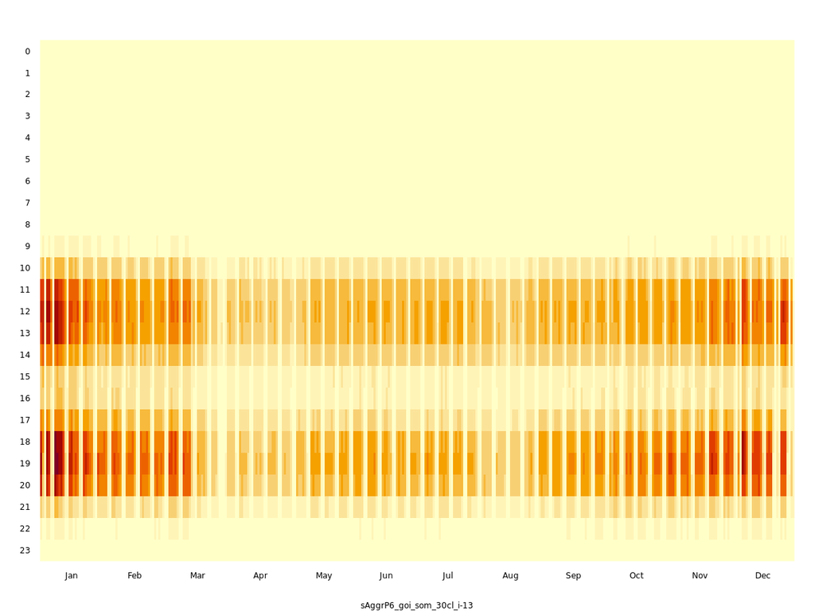

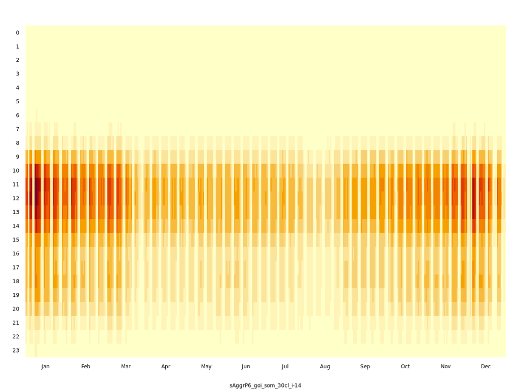

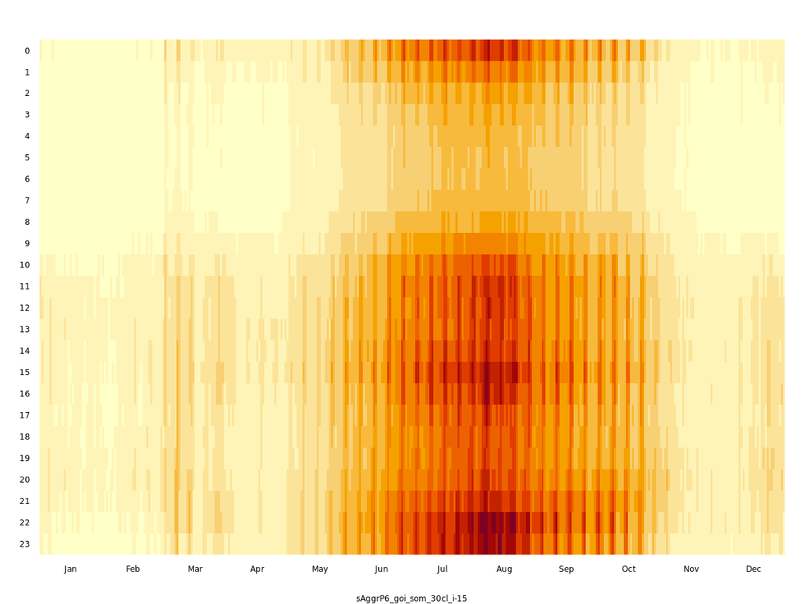

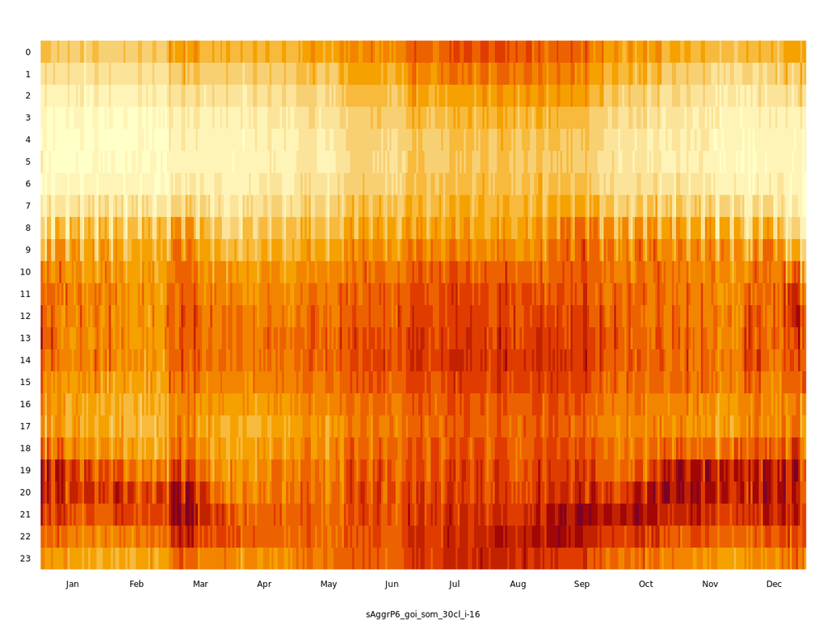

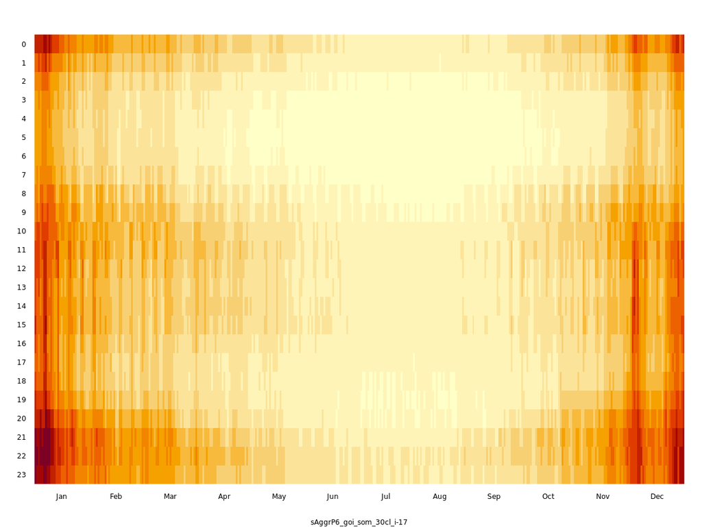

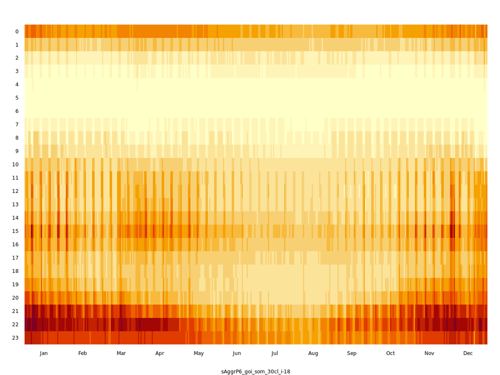

sAggrP6 > goi > som > #13

260 TS (1.6%)

sAggrP6 > goi > som > #14

512 TS (3.2%)

sAggrP6 > goi > som > #15

651 TS (4%)

sAggrP6 > goi > som > #16

1206 TS (7.5%)

sAggrP6 > goi > som > #17

544 TS (3.4%)

sAggrP6 > goi > som > #18

1489 TS (9.3%)

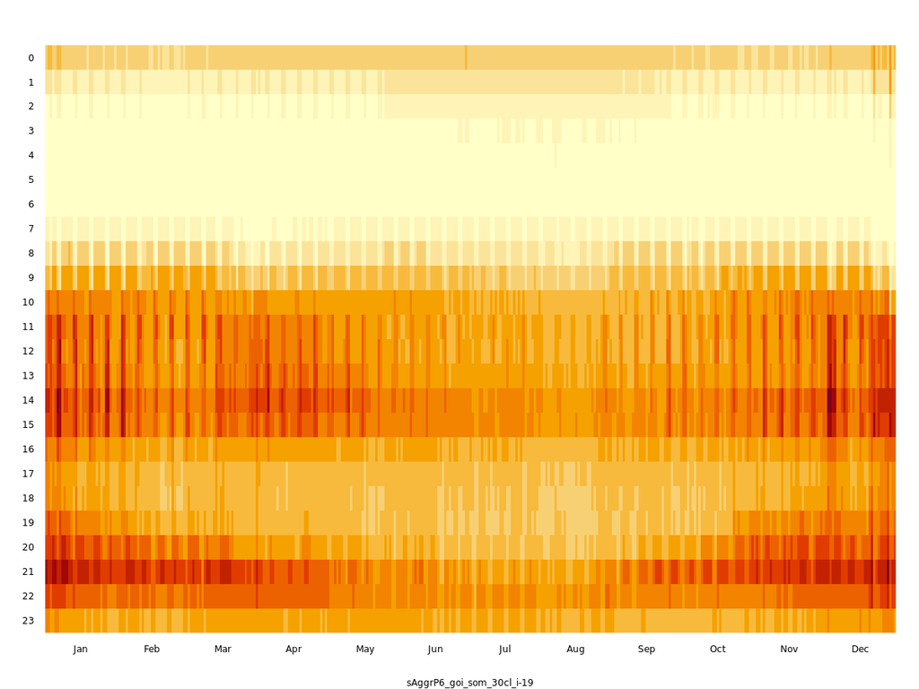

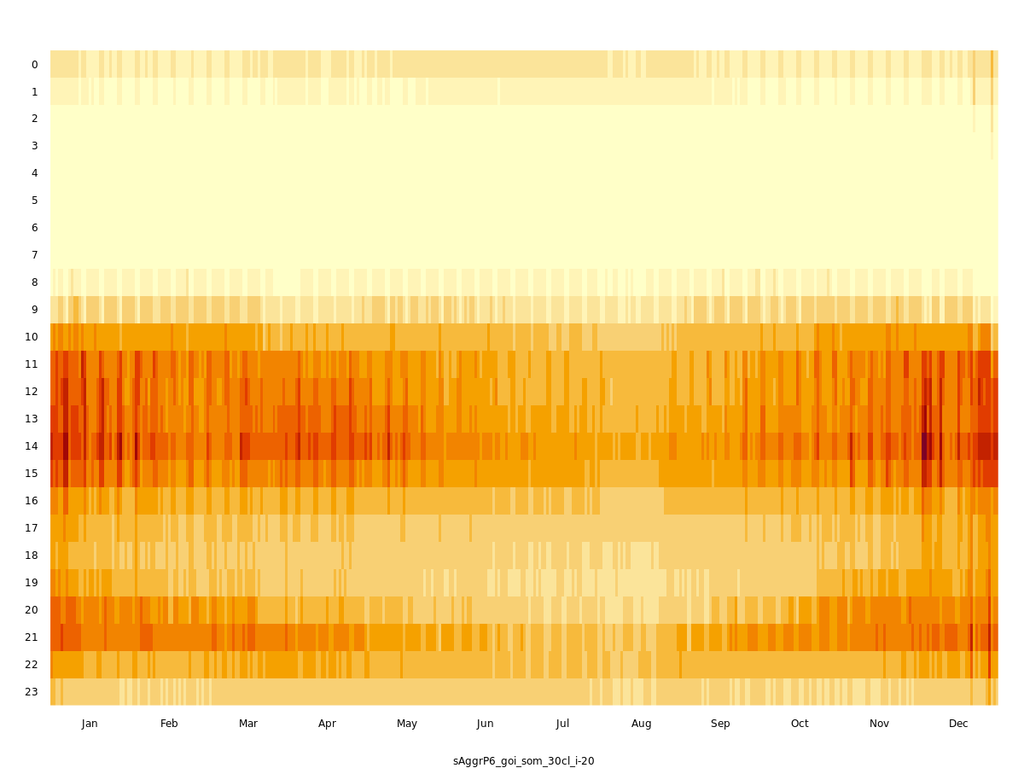

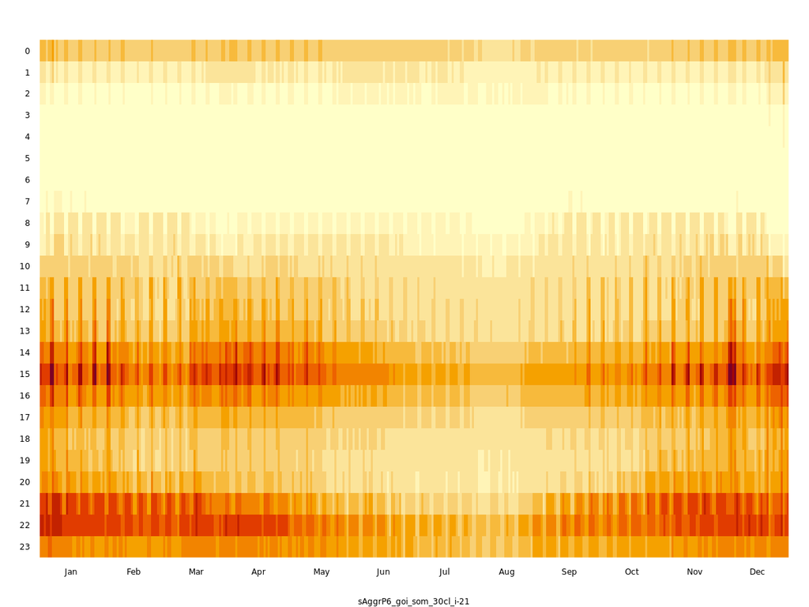

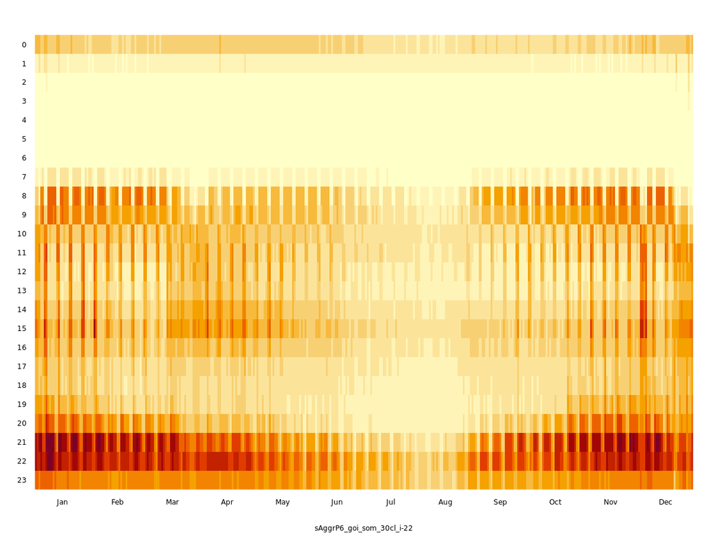

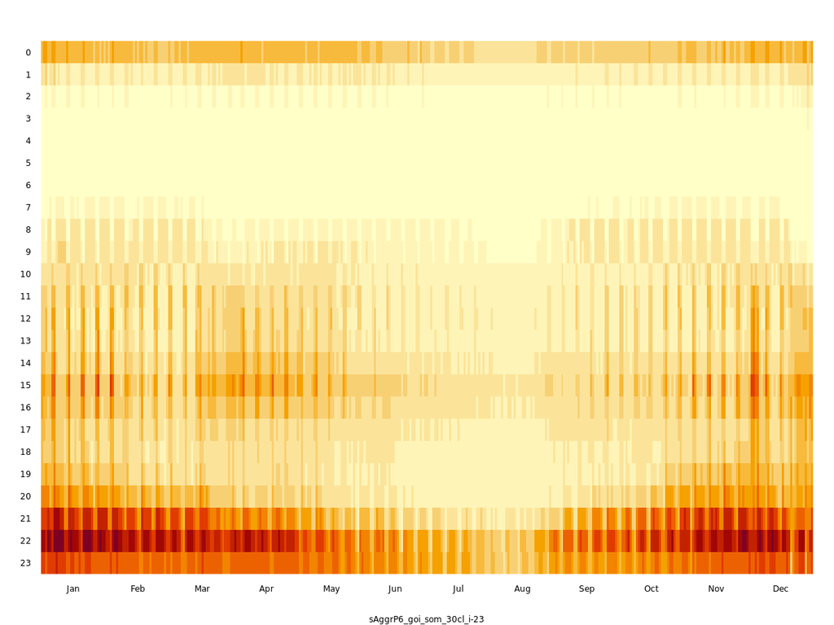

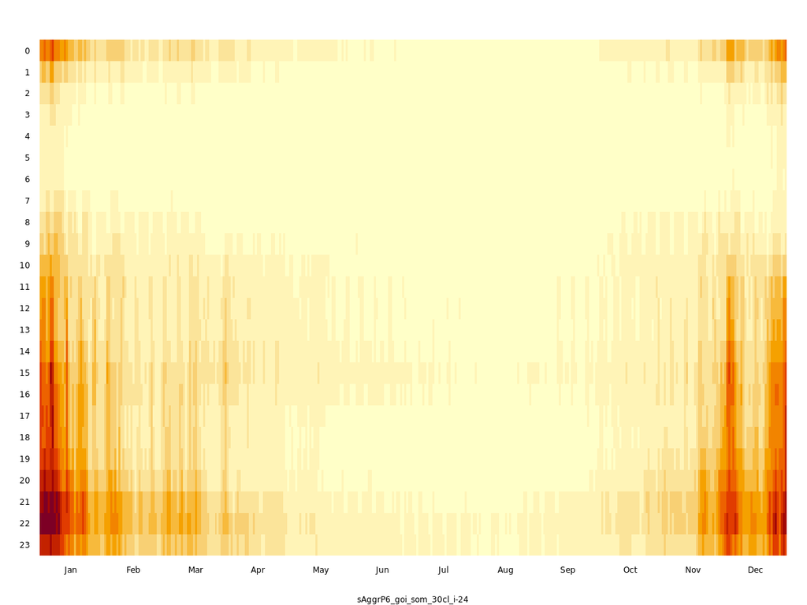

sAggrP6 > goi > som > #19

1670 TS (10.4%)

sAggrP6 > goi > som > #20

772 TS (4.8%)

sAggrP6 > goi > som > #21

1489 TS (9.3%)

sAggrP6 > goi > som > #22

1015 TS (6.3%)

sAggrP6 > goi > som > #23

926 TS (5.8%)

sAggrP6 > goi > som > #24

354 TS (2.2%)

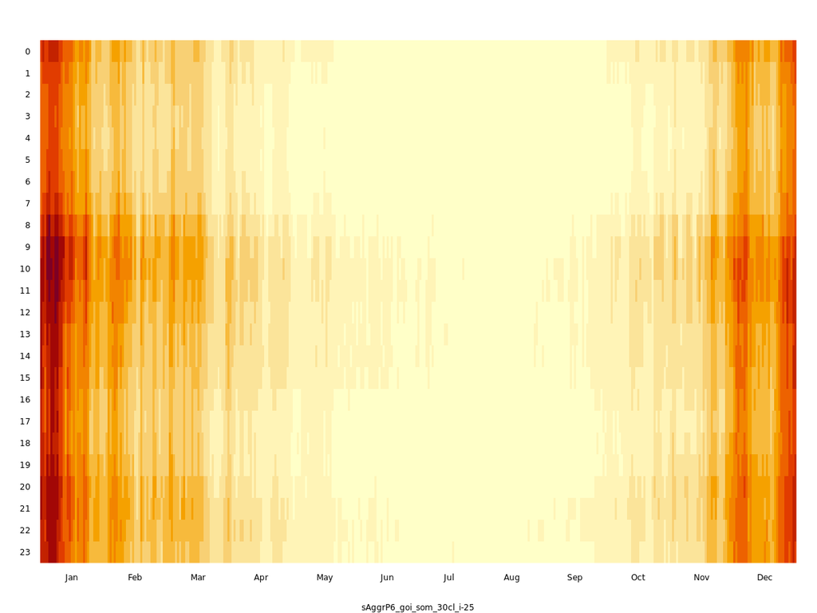

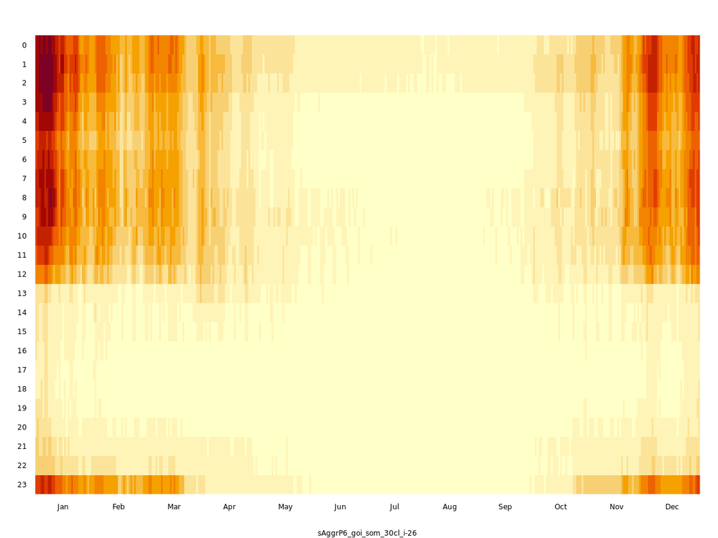

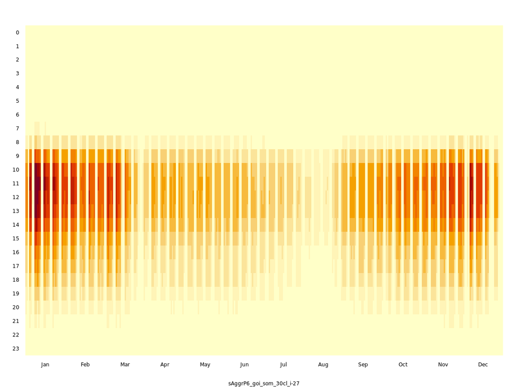

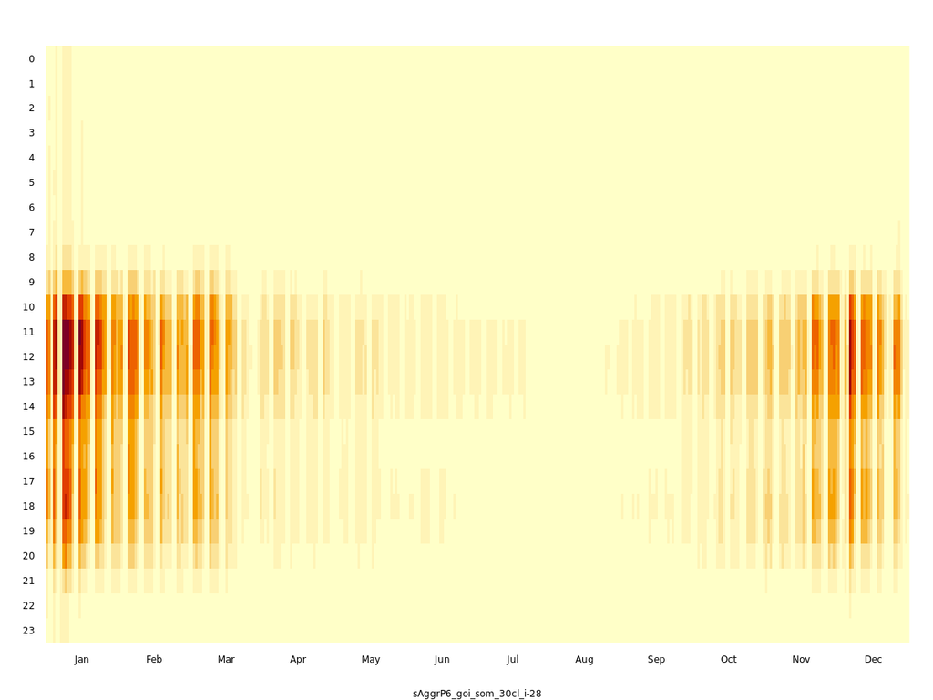

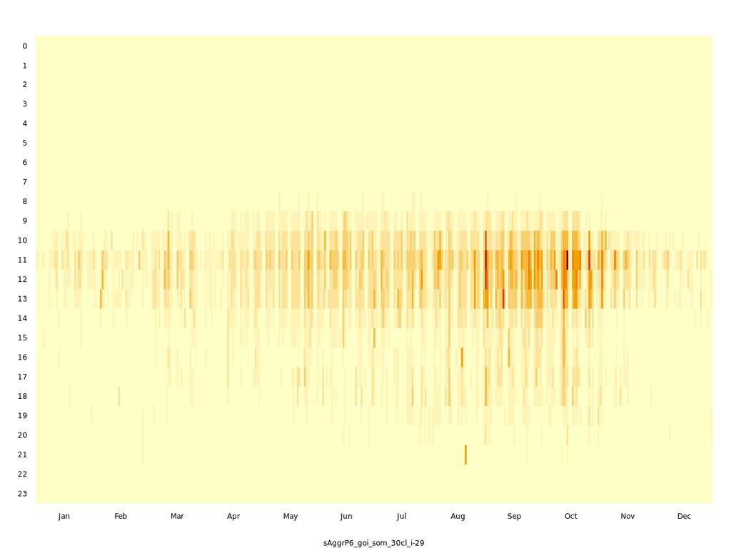

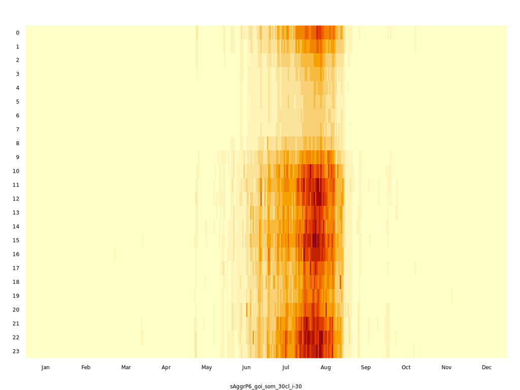

sAggrP6 > goi > som > #25

295 TS (1.8%)

sAggrP6 > goi > som > #26

179 TS (1.1%)

sAggrP6 > goi > som > #27

309 TS (1.9%)

sAggrP6 > goi > som > #28

230 TS (1.4%)

sAggrP6 > goi > som > #29

44 TS (0.3%)

sAggrP6 > goi > som > #30

125 TS (0.8%)

## sAggrDRM > goi > som

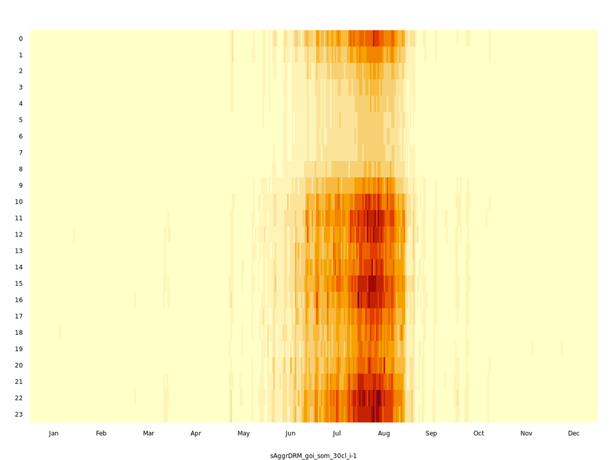

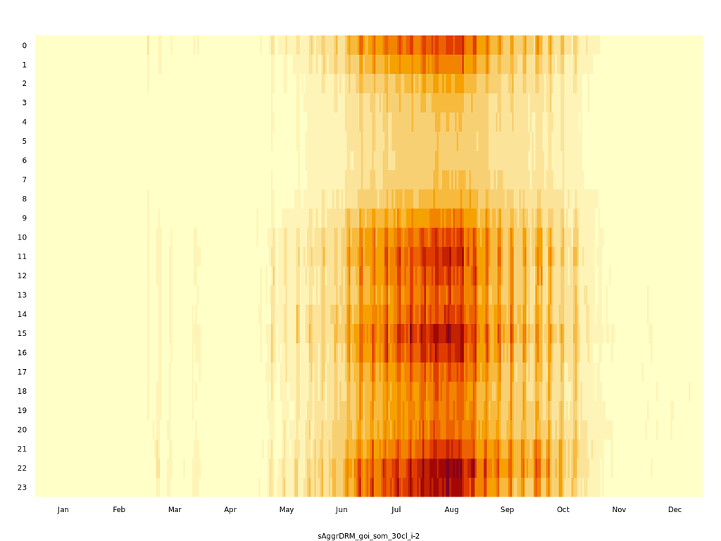

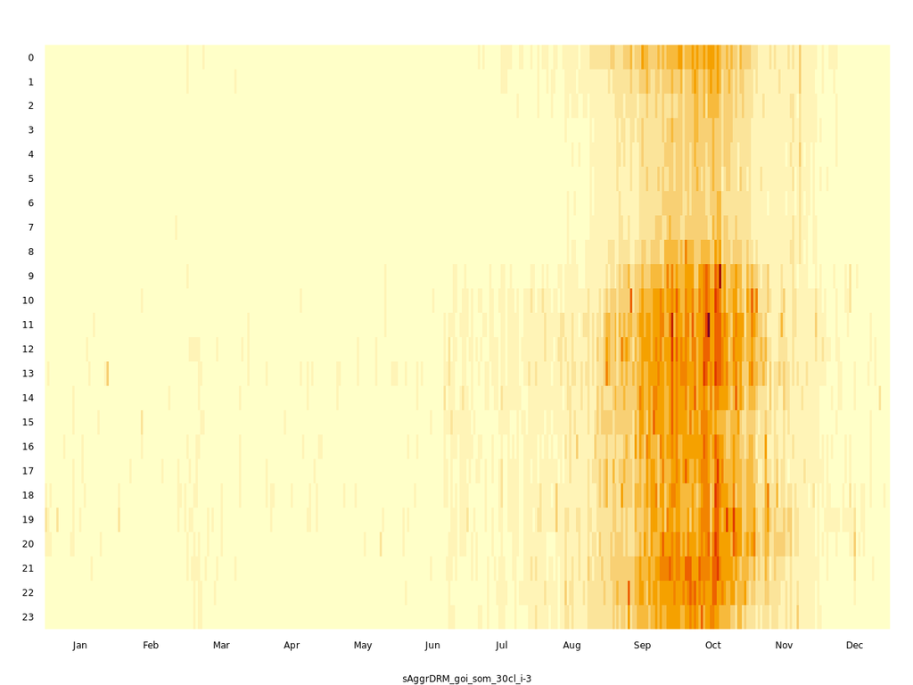

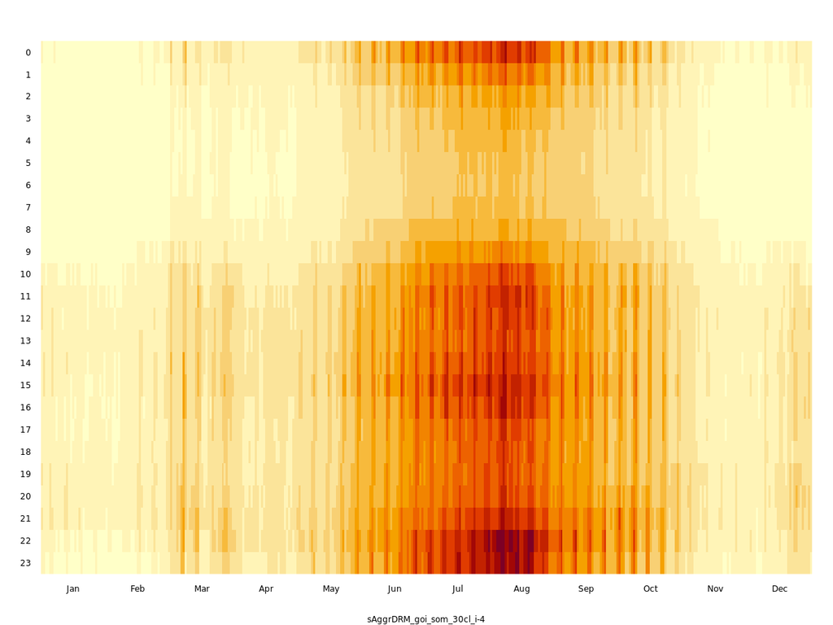

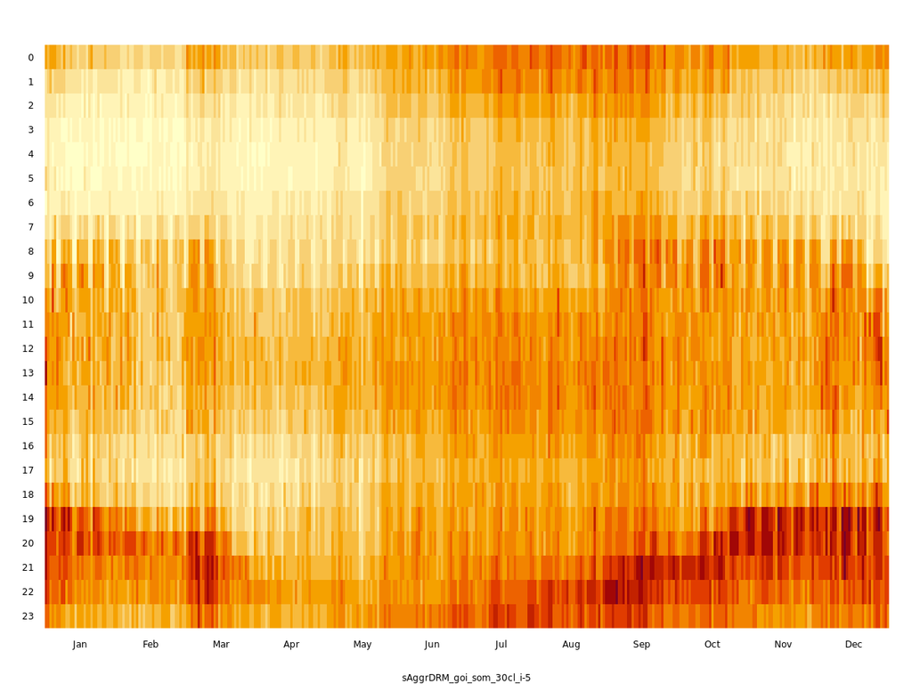

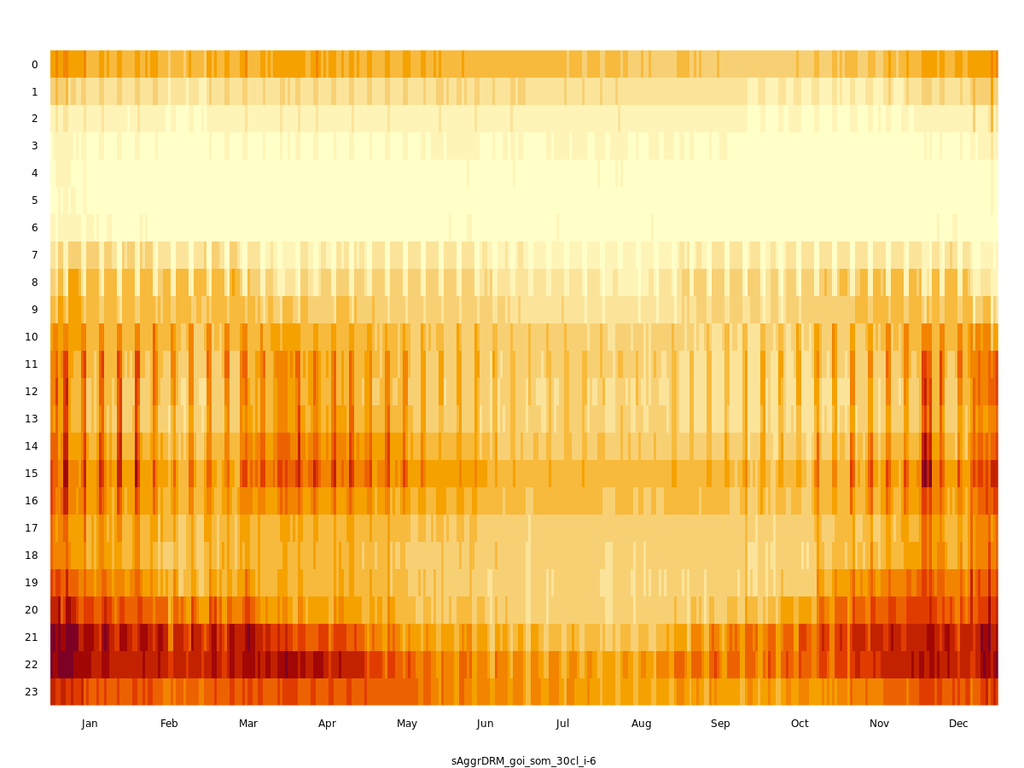

sAggrDRM > goi > som > #1

169 TS (1.1%)

sAggrDRM > goi > som > #2

252 TS (1.6%)

sAggrDRM > goi > som > #3

85 TS (0.5%)

sAggrDRM > goi > som > #4

605 TS (3.8%)

sAggrDRM > goi > som > #5

911 TS (5.7%)

sAggrDRM > goi > som > #6

1489 TS (9.3%)

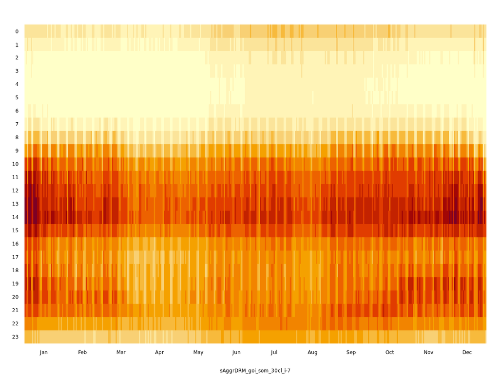

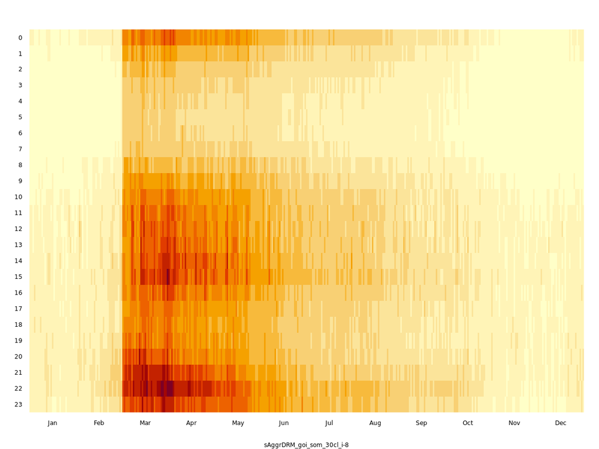

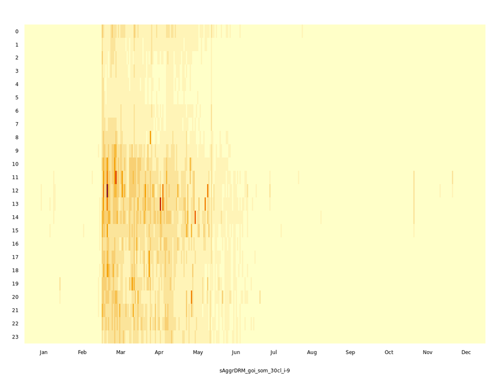

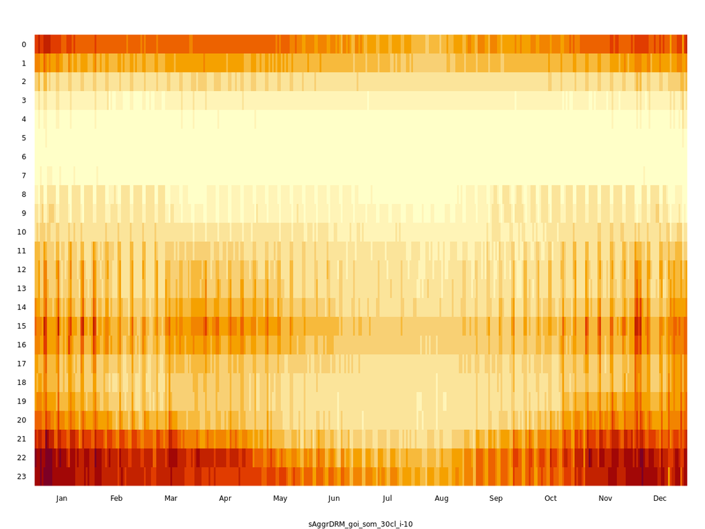

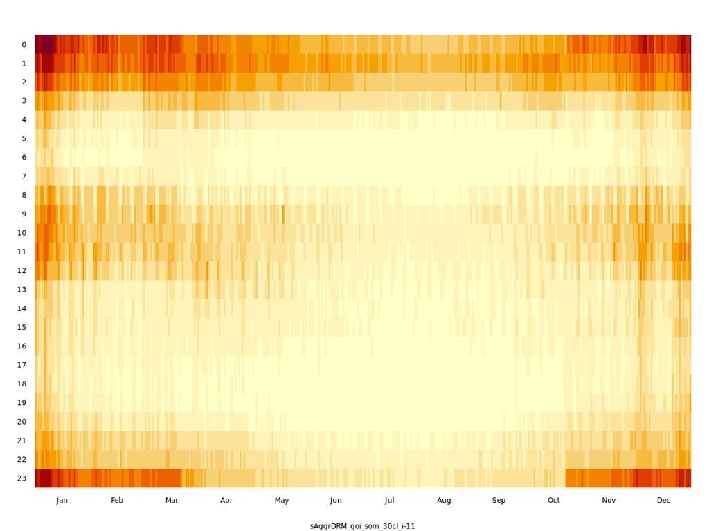

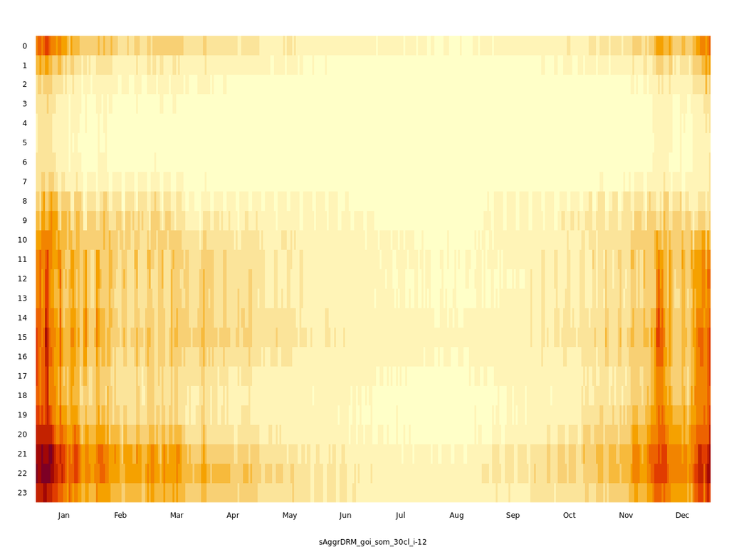

sAggrDRM > goi > som > #7

933 TS (5.8%)

sAggrDRM > goi > som > #8

250 TS (1.6%)

sAggrDRM > goi > som > #9

45 TS (0.3%)

sAggrDRM > goi > som > #10

927 TS (5.8%)

sAggrDRM > goi > som > #11

126 TS (0.8%)

sAggrDRM > goi > som > #12

700 TS (4.3%)

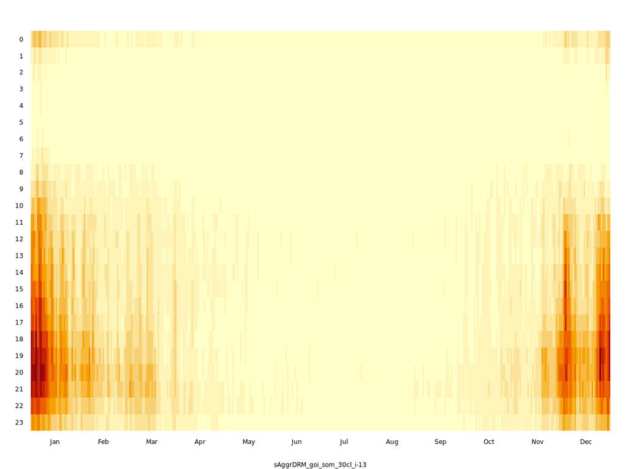

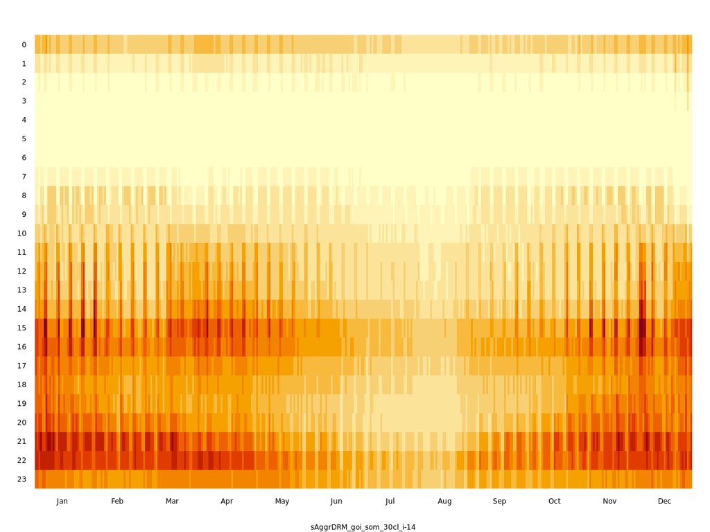

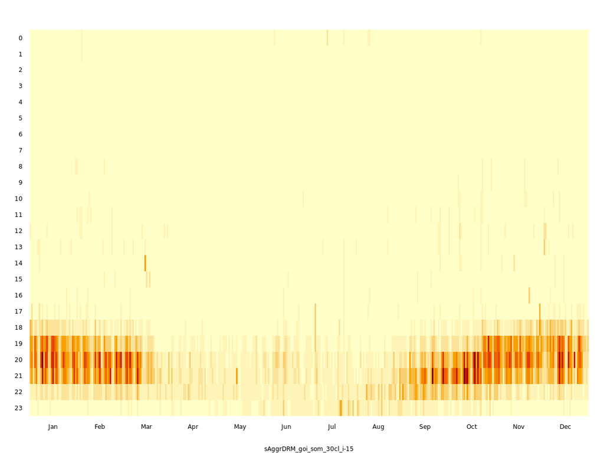

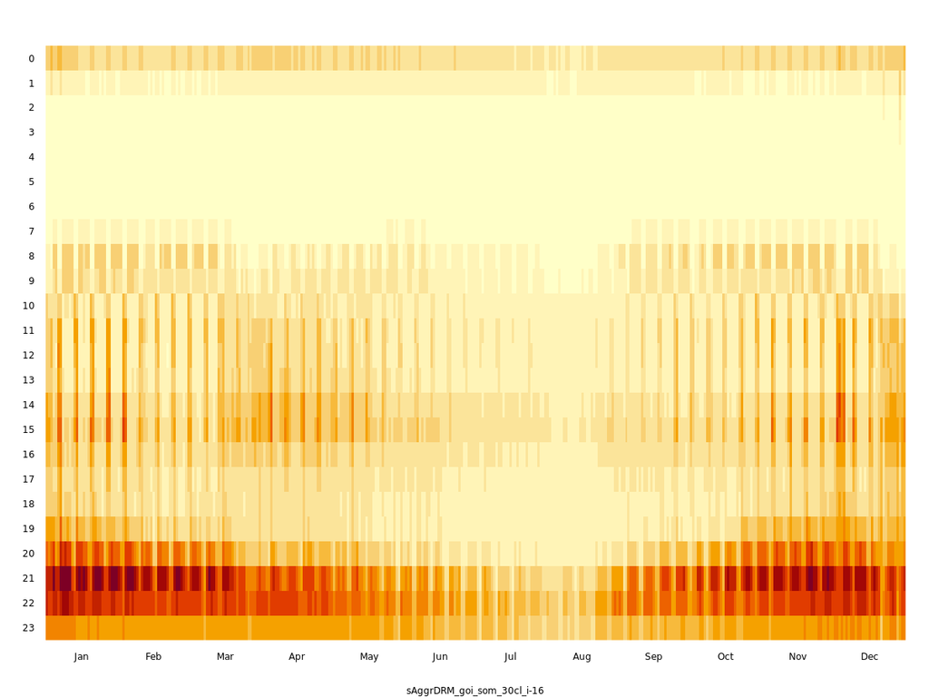

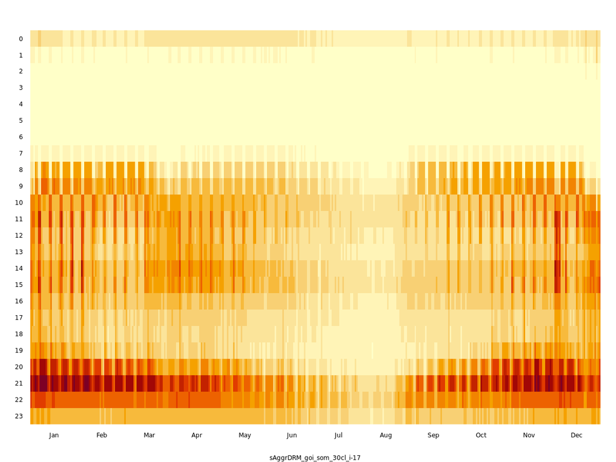

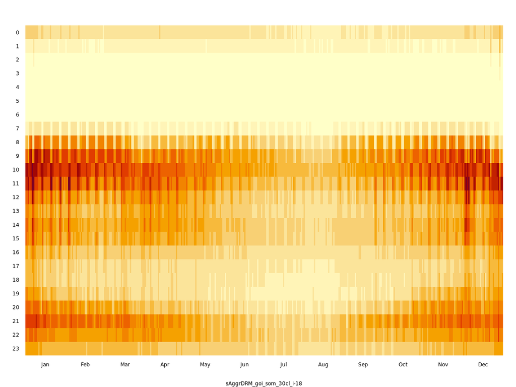

sAggrDRM > goi > som > #13

127 TS (0.8%)

sAggrDRM > goi > som > #14

1032 TS (6.4%)

sAggrDRM > goi > som > #15

45 TS (0.3%)

sAggrDRM > goi > som > #16

1121 TS (7%)

sAggrDRM > goi > som > #17

1198 TS (7.4%)

sAggrDRM > goi > som > #18

951 TS (5.9%)

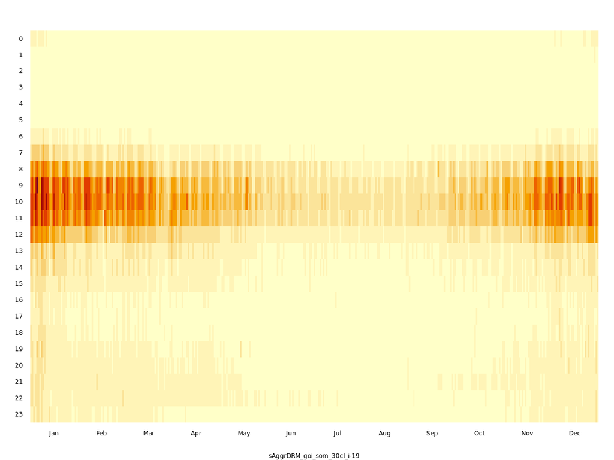

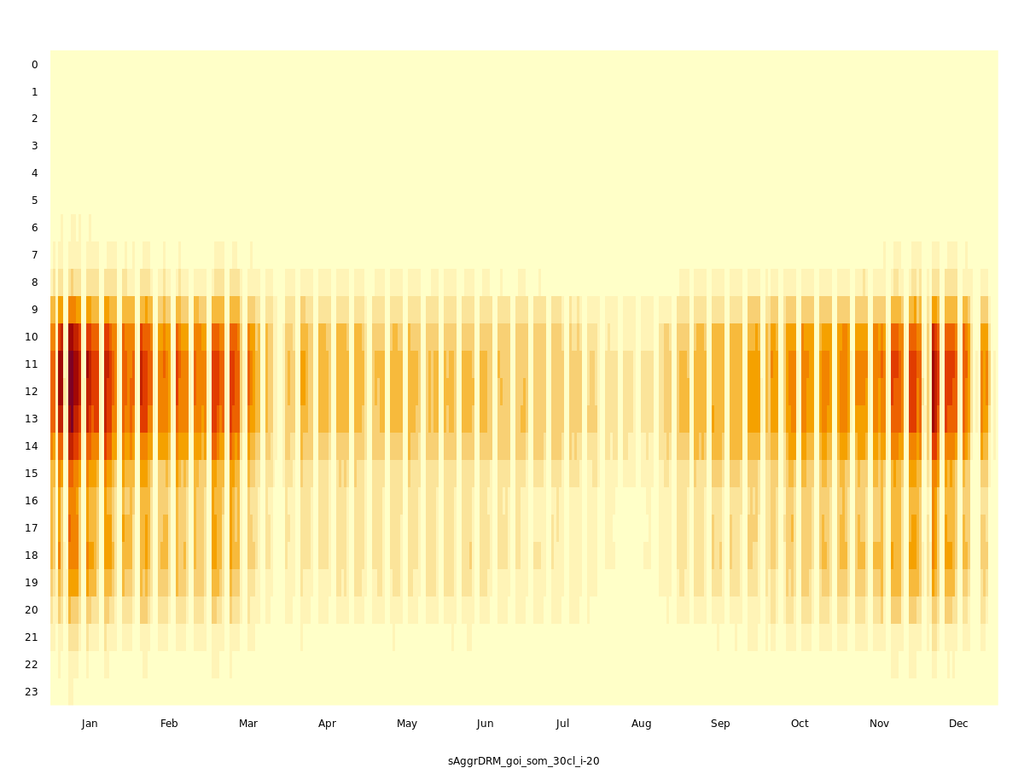

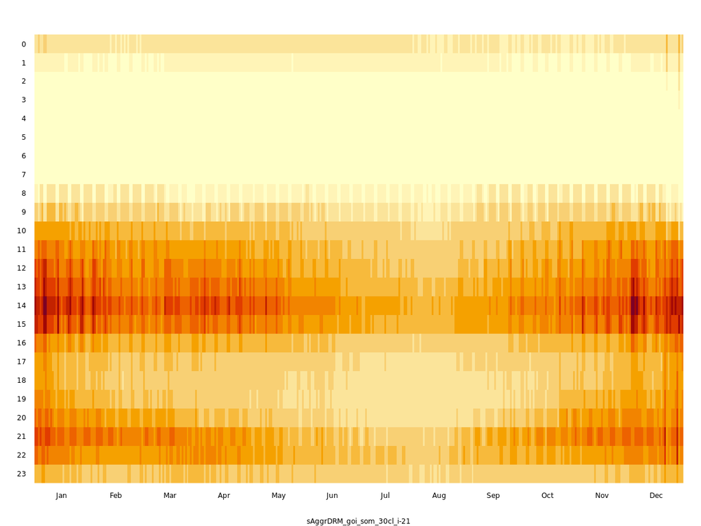

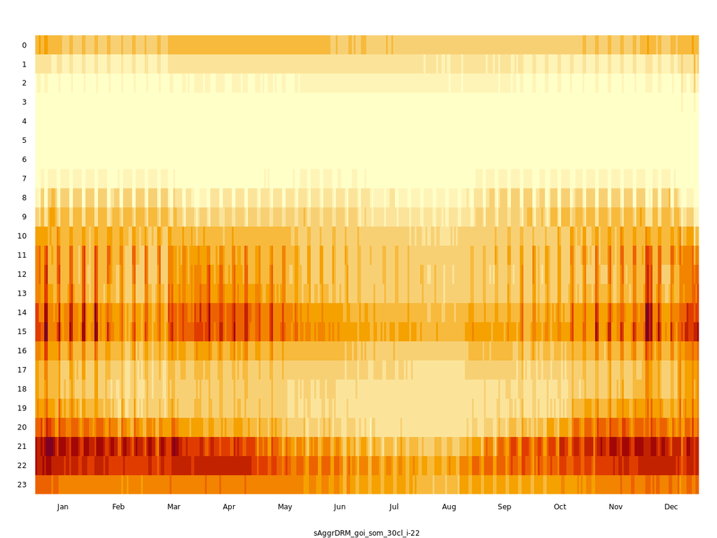

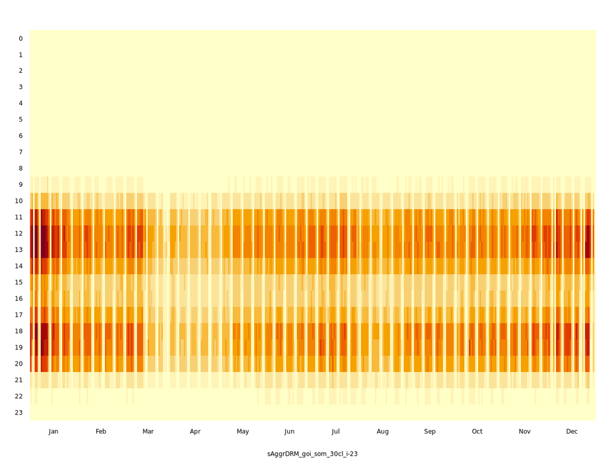

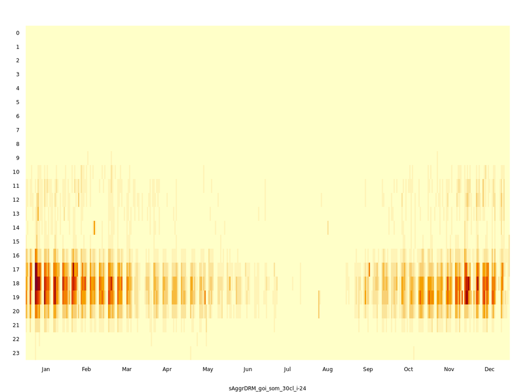

sAggrDRM > goi > som > #19

71 TS (0.4%)

sAggrDRM > goi > som > #20

504 TS (3.1%)

sAggrDRM > goi > som > #21

1120 TS (7%)

sAggrDRM > goi > som > #22

1832 TS (11.4%)

sAggrDRM > goi > som > #23

196 TS (1.2%)

sAggrDRM > goi > som > #24

56 TS (0.3%)

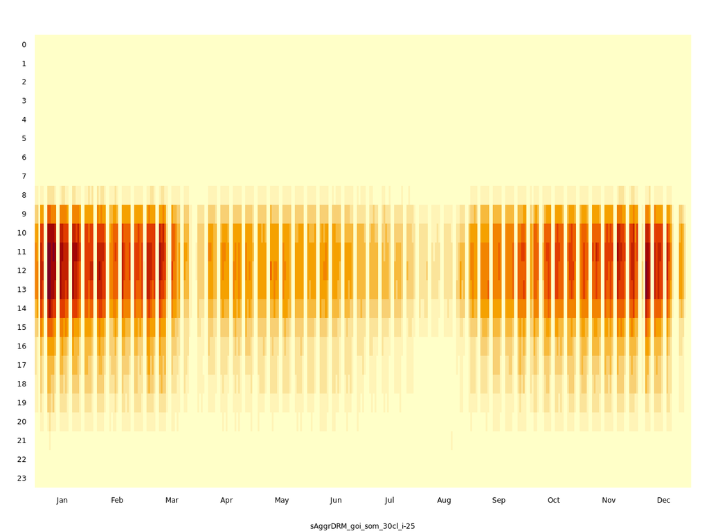

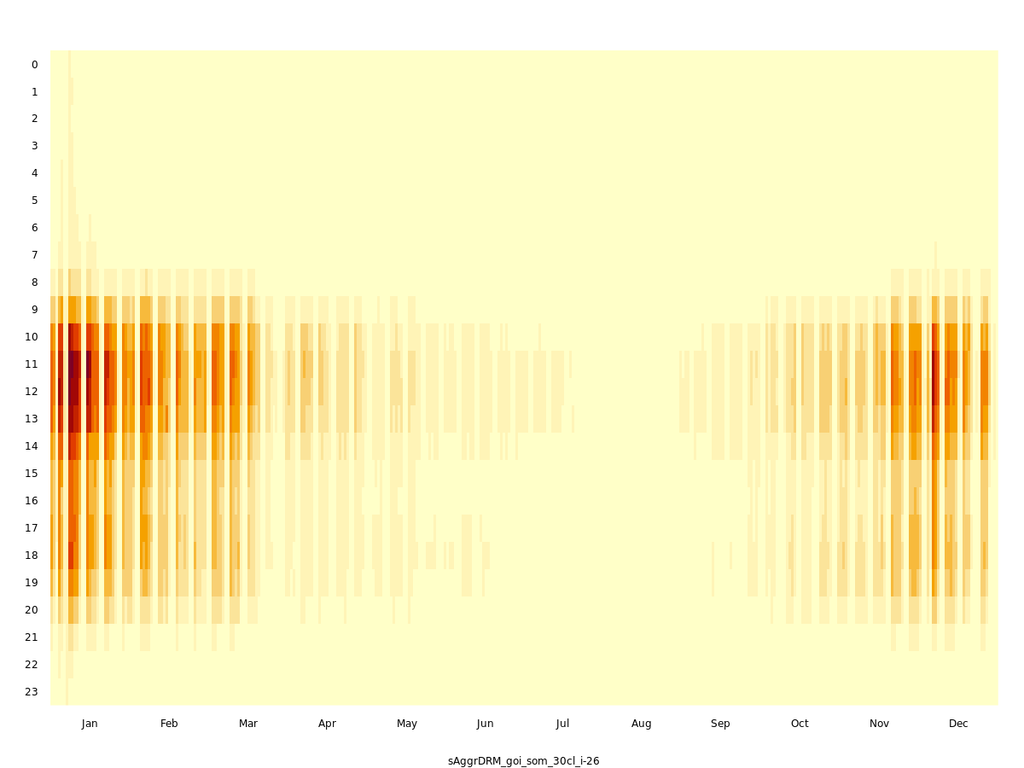

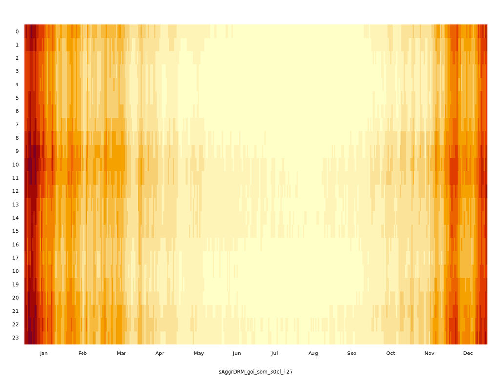

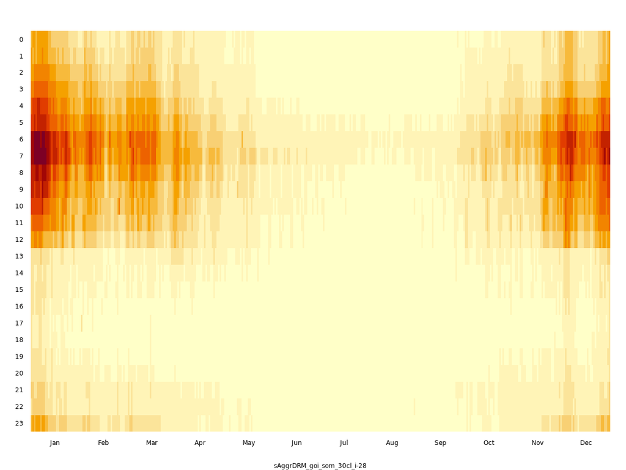

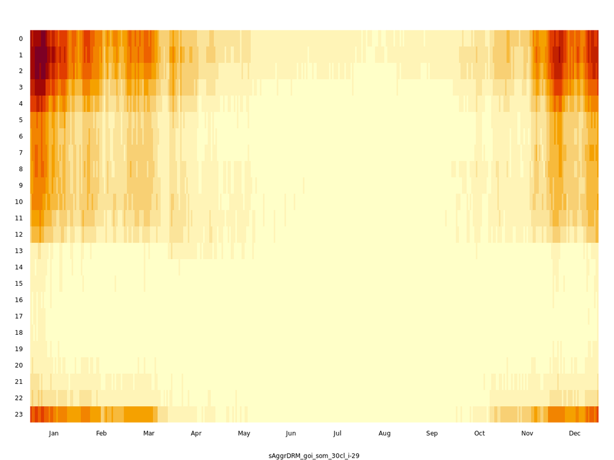

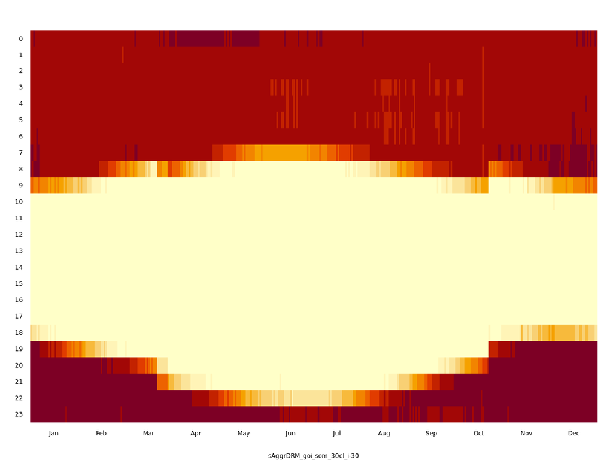

sAggrDRM > goi > som > #25

188 TS (1.2%)

sAggrDRM > goi > som > #26

196 TS (1.2%)

sAggrDRM > goi > som > #27

385 TS (2.4%)

sAggrDRM > goi > som > #28

94 TS (0.6%)

sAggrDRM > goi > som > #29

88 TS (0.5%)

sAggrDRM > goi > som > #30

399 TS (2.5%)